# Optimisation de l’analyse de risque de crédit grâce à la régression par variables instrumentales : Cas d’application et guide complet du package $ivreg$

Serge GNACADJA

# Introduction

L’évaluation des risques de crédit est un enjeu crucial dans le domaine de la finance, influençant directement les décisions des institutions bancaires et financières. Toutefois, l’analyse de ces risques est souvent entravée par des problèmes d’endogénéité, où les variables explicatives sont corrélées avec les erreurs de modélisation. Ce phénomène biaise les estimations et rend difficile une évaluation précise des facteurs influençant les comportements des emprunteurs.

La **régression par variables instrumentales (IV)** offre une solution robuste à ces défis. Contrairement à la régression classique, cette méthode permet de surmonter les biais d’endogénéité en introduisant des instruments exogènes, c’est-à-dire des variables corrélées aux variables explicatives endogènes mais indépendantes des résidus du modèle. La forme générique d’une régression IV peut être exprimée comme suit :

$$y = X\beta + \varepsilon \quad \text{avec} \quad Z'X \neq 0 \quad
\text{et} \quad Z'\varepsilon = 0$$

Où :  
- $y$ représente la variable dépendante, ici le **statut du prêt**.  
- $X$ correspond aux variables explicatives potentiellement endogènes.  
- $Z$ est le vecteur des variables instrumentales exogènes.

Cette approche a démontré son efficacité dans l’analyse des comportements financiers, notamment en isolant les effets spécifiques de variables clés comme le montant emprunté, le taux d’intérêt, ou encore la proportion de revenu consacrée au remboursement. Ce travail se concentre sur l’application de cette méthode à une base de données sur le risque de crédit, tout en introduisant le package **`ivreg`**, qui facilite sa mise en œuvre dans R.

# Problématique

Comment surmonter les biais d’endogénéité dans les modèles d’analyse de risque de crédit afin de produire des résultats plus fiables et exploitables pour les décideurs financiers ?

# I. Exploration de la base de données

Notre $Dataset$ nous vient tout droit de $Kaggle$. Pour ceux qui sont intéressés(es) par cela, vous pouvez cliquez [ici](https://www.kaggle.com/datasets/laotse/credit-risk-dataset). Nous avons eu 32,581 observations de 12 variables.

```r
if (!require("readr")) install.packages("readr")
credit_risk_dataset = read_csv("~/Applis/GMM3/Stat. Multi. Varié/project/credit_risk_dataset.csv")

summary(credit_risk_dataset)
```

```
##    person_age     person_income     person_home_ownership person_emp_length
##  Min.   : 20.00   Min.   :   4000   Length:32581          Min.   :  0.00
##  1st Qu.: 23.00   1st Qu.:  38500   Class :character      1st Qu.:  2.00
##  Median : 26.00   Median :  55000   Mode  :character      Median :  4.00
##  Mean   : 27.73   Mean   :  66075                         Mean   :  4.79
##  3rd Qu.: 30.00   3rd Qu.:  79200                         3rd Qu.:  7.00
##  Max.   :144.00   Max.   :6000000                         Max.   :123.00
##                                                           NA's   :895
##  loan_intent         loan_grade          loan_amnt     loan_int_rate
##  Length:32581       Length:32581       Min.   :  500   Min.   : 5.42
##  Class :character   Class :character   1st Qu.: 5000   1st Qu.: 7.90
##  Mode  :character   Mode  :character   Median : 8000   Median :10.99
##                                        Mean   : 9589   Mean   :11.01
##                                        3rd Qu.:12200   3rd Qu.:13.47
##                                        Max.   :35000   Max.   :23.22
##                                                        NA's   :3116
##   loan_status     loan_percent_income cb_person_default_on_file
##  Min.   :0.0000   Min.   :0.0000      Length:32581
##  1st Qu.:0.0000   1st Qu.:0.0900      Class :character
##  Median :0.0000   Median :0.1500      Mode  :character
##  Mean   :0.2182   Mean   :0.1702
##  3rd Qu.:0.0000   3rd Qu.:0.2300
##  Max.   :1.0000   Max.   :0.8300
##
##  cb_person_cred_hist_length
##  Min.   : 2.000
##  1st Qu.: 3.000
##  Median : 4.000
##  Mean   : 5.804
##  3rd Qu.: 8.000
##  Max.   :30.000
##
```

## I.1 Récapitulatif

Nous avons 4 variables qualitatives et donc 8 quantitatives dont $3\%$ de $person\_emp\_length$ et $9.5\%$ de $loan\_int\_rate$ sont manquantes.

| Nom de la variable | Description | Nature de la variable |
| --- | --- | --- |
| `person_age` | Âge de la personne | Continue |
| `person_income` | Revenu annuel de la personne | Continue |
| `person_home_ownership` | Propriété du logement (par exemple, propriétaire, locataire) | Qualitative |
| `person_emp_length` | Durée de l’emploi en années | Continue |
| `loan_intent` | Intention du prêt (par exemple, achat, consolidation de dettes) | Qualitative |
| `loan_grade` | Note de crédit du prêt (par exemple, A, B, C) | Qualitative |
| `loan_amnt` | Montant du prêt | Continue |
| `loan_int_rate` | Taux d’intérêt du prêt | Continue |
| `loan_status` | Statut du prêt (0 pour non-défaut, 1 pour défaut) | Discrète |
| `loan_percent_income` | Pourcentage du revenu consacré au prêt | Continue |
| `cb_person_default_on_file` | Historique de défaut de paiement (True/False) | Qualitative |
| `cb_person_cred_hist_length` | Durée de l’historique de crédit en années | Continue |

# II. Préparation des Données

Nous avons remarqué des valeurs manquantes ainsi que des valeurs aberrantes dans nos données. Il est ainsi nécessaire de les traiter.

## II.1 Suppression des valeurs manquantes

```r
# Supprimer toutes les lignes contenant au moins une valeur manquante
data_cleaned <- na.omit(credit_risk_dataset)

# Vérifier le résultat
print(dim(data_cleaned))
```

```
## [1] 28638    12
```

```r
summary(data_cleaned)
```

```
##    person_age     person_income     person_home_ownership person_emp_length
##  Min.   : 20.00   Min.   :   4000   Length:28638          Min.   :  0.000
##  1st Qu.: 23.00   1st Qu.:  39480   Class :character      1st Qu.:  2.000
##  Median : 26.00   Median :  55956   Mode  :character      Median :  4.000
##  Mean   : 27.73   Mean   :  66649                         Mean   :  4.789
##  3rd Qu.: 30.00   3rd Qu.:  80000                         3rd Qu.:  7.000
##  Max.   :144.00   Max.   :6000000                         Max.   :123.000
##  loan_intent         loan_grade          loan_amnt     loan_int_rate
##  Length:28638       Length:28638       Min.   :  500   Min.   : 5.42
##  Class :character   Class :character   1st Qu.: 5000   1st Qu.: 7.90
##  Mode  :character   Mode  :character   Median : 8000   Median :10.99
##                                        Mean   : 9656   Mean   :11.04
##                                        3rd Qu.:12500   3rd Qu.:13.48
##                                        Max.   :35000   Max.   :23.22
##   loan_status     loan_percent_income cb_person_default_on_file
##  Min.   :0.0000   Min.   :0.0000      Length:28638
##  1st Qu.:0.0000   1st Qu.:0.0900      Class :character
##  Median :0.0000   Median :0.1500      Mode  :character
##  Mean   :0.2166   Mean   :0.1695
##  3rd Qu.:0.0000   3rd Qu.:0.2300
##  Max.   :1.0000   Max.   :0.8300
##  cb_person_cred_hist_length
##  Min.   : 2.000
##  1st Qu.: 3.000
##  Median : 4.000
##  Mean   : 5.794
##  3rd Qu.: 8.000
##  Max.   :30.000
```

## II.2- Suppression des valeurs abberrantes

```r
# Suppression des lignes où l'âge est < à 18 et > 90
data_cleaned <- data_cleaned[data_cleaned$person_age >= 18 & data_cleaned$person_age <= 90, ]

# Suppression des lignes où la durée de l'emploi est supérieure à l'âge
credit_data_clean <- data_cleaned[data_cleaned$person_emp_length <= data_cleaned$person_age - 16, ]

# Vérifier le résultat
print(dim(credit_data_clean))
```

```
## [1] 27973    12
```

```r
summary(credit_data_clean)
```

```
##    person_age    person_income     person_home_ownership person_emp_length
##  Min.   :20.00   Min.   :   4000   Length:27973          Min.   : 0.000
##  1st Qu.:23.00   1st Qu.:  39000   Class :character      1st Qu.: 2.000
##  Median :26.00   Median :  55530   Mode  :character      Median : 4.000
##  Mean   :27.78   Mean   :  66386                         Mean   : 4.661
##  3rd Qu.:30.00   3rd Qu.:  80000                         3rd Qu.: 7.000
##  Max.   :84.00   Max.   :2039784                         Max.   :41.000
##  loan_intent         loan_grade          loan_amnt     loan_int_rate
##  Length:27973       Length:27973       Min.   :  500   Min.   : 5.42
##  Class :character   Class :character   1st Qu.: 5000   1st Qu.: 7.90
##  Mode  :character   Mode  :character   Median : 8000   Median :10.99
##                                        Mean   : 9639   Mean   :11.04
##                                        3rd Qu.:12400   3rd Qu.:13.48
##                                        Max.   :35000   Max.   :23.22
##   loan_status     loan_percent_income cb_person_default_on_file
##  Min.   :0.0000   Min.   :0.0000      Length:27973
##  1st Qu.:0.0000   1st Qu.:0.0900      Class :character
##  Median :0.0000   Median :0.1500      Mode  :character
##  Mean   :0.2169   Mean   :0.1693
##  3rd Qu.:0.0000   3rd Qu.:0.2300
##  Max.   :1.0000   Max.   :0.8300
##  cb_person_cred_hist_length
##  Min.   : 2.00
##  1st Qu.: 3.00
##  Median : 4.00
##  Mean   : 5.83
##  3rd Qu.: 8.00
##  Max.   :30.00
```

## II.3- Transformation des variables qualitatives

Les variables catégorielles doivent être converties en variables numériques pour être utilisées dans les modèles statistiques. Nous utilisons l’encodage one-hot pour cette transformation :

```r
if (!require("dplyr")) install.packages("dplyr")
if (!require("caret")) install.packages("caret")

# Transformation des variables catégorielles en facteurs
credit_data_clean$person_home_ownership <- as.factor(credit_data_clean$person_home_ownership)
credit_data_clean$loan_intent <- as.factor(credit_data_clean$loan_intent)
credit_data_clean$loan_grade <- as.factor(credit_data_clean$loan_grade)
credit_data_clean$cb_person_default_on_file <- as.factor(credit_data_clean$cb_person_default_on_file)

# Application de l'encodage one-hot
dummies <- dummyVars(~ person_home_ownership + loan_intent + loan_grade + cb_person_default_on_file, data = credit_data_clean)
credit_data_encoded <- predict(dummies, newdata = credit_data_clean)

# Combinaison des données encodées avec les variables numériques
credit_data <- cbind(credit_data_clean %>% select(-person_home_ownership, -loan_intent, -loan_grade, -cb_person_default_on_file), credit_data_encoded)

# Vérifier le résultat
print(dim(credit_data))
```

```
## [1] 27973    27
```

# III. Identification des variables endogènes

Dans la suite de notre analyse, on considération que les variables qualitative ainsi qu’on utilisera qu’une partie des données qu’on divisera en (70-30) dont 70% train et 30% test. On considéra juste un échantillon (5000 obs) de notre dataset qui un peu trop immense.

Les variables endogènes sont celles qui sont expliquées par d’autres variables du modèle. Pour les identifier, nous pouvons examiner les corrélations entre les variables et construire un modèle de régression multiple :

```r
if (!require("corrplot")) install.packages("corrplot")
if (!require("caret")) install.packages("caret")
set.seed(123)

# Variables Quantitative
var_quanti <- c('person_age', 'person_income', 'person_emp_length', 'loan_amnt', 'loan_int_rate', 'loan_status', 'loan_percent_income', 'cb_person_cred_hist_length')
dataVarQuanti <- credit_data[var_quanti]

# Sélection aléatoire de 5000 obs
data <- dataVarQuanti %>% sample_n(5000)
print("Dimension après échantillonage")
```

```
## [1] "Dimension après échantillonage"
```

```r
print(dim(data))
```

```
## [1] 5000    8
```

```r
# Séparation des données (70% train, 30% test)
train_index <- createDataPartition(data$loan_status, p = 0.7, list = FALSE)
## Train 0.7
train_data <- data[train_index, ]
print("Dimension du train")
```

```
## [1] "Dimension du train"
```

```r
print(dim(train_data))
```

```
## [1] 3500    8
```

```r
## Test 0.3
test_data <- data[-train_index, ]
print("Dimension du test")
```

```
## [1] "Dimension du test"
```

```r
print(dim(test_data))
```

```
## [1] 1500    8
```

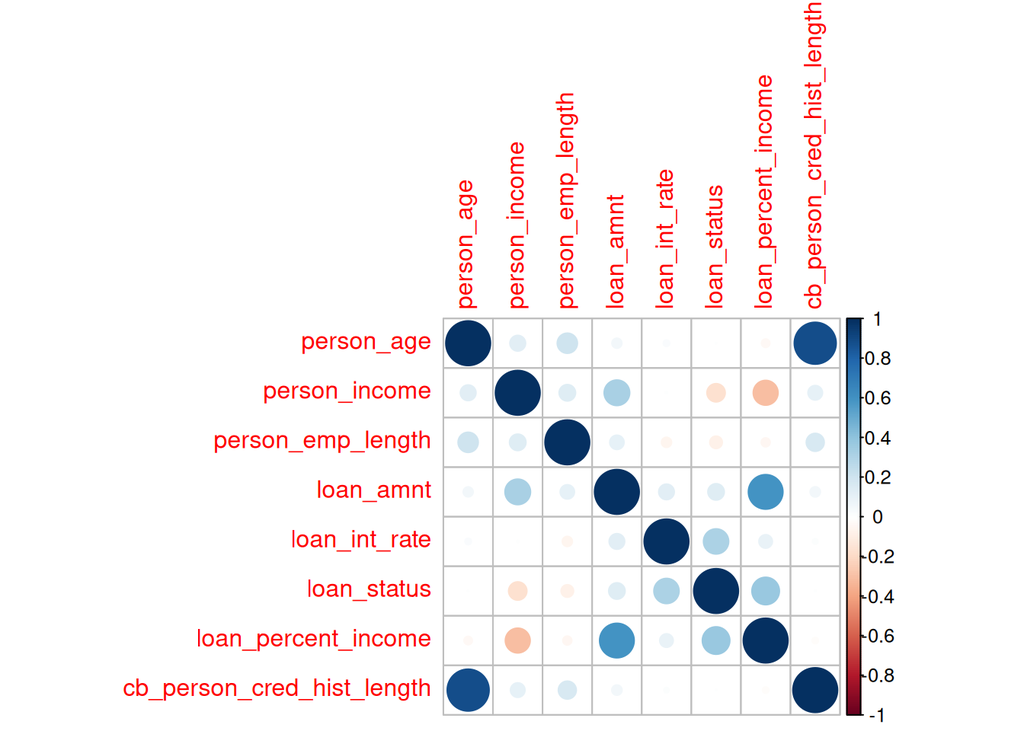

```r
# Calcul de la matrice de corrélation
cor_matrix <- cor(train_data)

# Visualisation de la matrice de corrélation
corrplot(cor_matrix, method = "circle")
```

## III.1- Analyse de la matrice de corrélation (focalisée sur $loan\_status$)

### Variables avec corrélation directe avec $loan\_status$ :

- $loan\_amnt$ : Corrélation faible (0.14).
- $loan\_percent\_income$ : Corrélation modérée (0.38).
- $loan\_int\_rate$ : Corrélation modérée (0.32).

Ces variables sont liées à $loan\_status$, mais pour déterminer l’endogénéité, il faut aussi examiner leurs relations avec d’autres variables explicatives.

### Corrélations entre variables explicatives :

1. $loan\_amnt$
- Modérément corrélée avec $person\_income$ (0.33).
- Fortement corrélée avec $loan\_percent\_income$ (~0.6).
2. $loan\_percent\_income$
- Forte corrélation avec $loan\_amnt$.
- Modérément corrélée avec $person\_income$ (~-0.3).
3. $loan\_int\_rate$
- Faiblement corrélée avec $loan\_amnt$ et $loan\_percent\_income$.

### Conclusion basée sur cette analyse :

Variables potentiellement endogènes :

1. $loan\_amnt$ : Fortement corrélée avec $loan\_percent\_income$ et $person\_income$, indiquant qu’elle pourrait être influencée par des facteurs non observés.
2. $loan\_percent\_income$ : Endogénéité potentielle due à sa relation avec $loan\_amnt$ et $loan\_status$.
3. $loan\_int\_rate$ : Moins suspecte mais corrélée avec d’autres variables explicatives.

# VI. Régression de Variables Instrumentales

## VI.1- Modèle 1

Ici on a utilisé un modèle avec $loan\_amnt$ comme endogène et $cb\_person\_cred\_hist\_length$ comme instrument

```r
library(AER)

iv_model1 <- ivreg(loan_status ~ loan_amnt + loan_percent_income + loan_int_rate | cb_person_cred_hist_length + loan_percent_income + loan_int_rate,
                  data = train_data)

summary(iv_model1, diagnostics = TRUE)
```

```
##
## Call:
## ivreg(formula = loan_status ~ loan_amnt + loan_percent_income +
##     loan_int_rate | cb_person_cred_hist_length + loan_percent_income +
##     loan_int_rate, data = train_data)
##
## Residuals:
##     Min      1Q  Median      3Q     Max
## -0.8799 -0.2415 -0.1004  0.0926  1.1517
##
## Coefficients:
##                       Estimate Std. Error t value Pr(>|t|)
## (Intercept)         -4.250e-01  4.151e-02 -10.239   <2e-16 ***
## loan_amnt            4.597e-06  1.531e-05   0.300   0.7640
## loan_percent_income  1.183e+00  5.367e-01   2.204   0.0276 *
## loan_int_rate        3.577e-02  2.811e-03  12.724   <2e-16 ***
##
## Diagnostic tests:
##                   df1  df2 statistic p-value
## Weak instruments    1 3496    22.488 2.2e-06 ***
## Wu-Hausman          1 3495     1.119    0.29
## Sargan              0   NA        NA      NA
## ---
## Signif. codes:  0 '***' 0.001 '**' 0.01 '*' 0.05 '.' 0.1 ' ' 1
##
## Residual standard error: 0.3674 on 3496 degrees of freedom
## Multiple R-Squared: 0.2045,  Adjusted R-squared: 0.2038
## Wald test: 327.2 on 3 and 3496 DF,  p-value: < 2.2e-16
```

## VI.2- Modèle 2

Ici on a utilisé un modèle avec $loan\_amnt$ comme endogène et $person\_income$, $loan\_percent\_income$ comme instruments

```r
library(AER)

iv_model2 <- ivreg(loan_status ~ loan_amnt  + loan_int_rate + person_emp_length + person_age  | person_income + loan_percent_income  + loan_int_rate   + person_emp_length + person_age,
                  data = train_data)

summary(iv_model2, diagnostics = TRUE)
```

```
##
## Call:
## ivreg(formula = loan_status ~ loan_amnt + loan_int_rate + person_emp_length +
##     person_age | person_income + loan_percent_income + loan_int_rate +
##     person_emp_length + person_age, data = train_data)
##
## Residuals:
##      Min       1Q   Median       3Q      Max
## -0.95800 -0.25227 -0.12049  0.06161  1.21266
##
## Coefficients:
##                     Estimate Std. Error t value Pr(>|t|)
## (Intercept)       -3.075e-01  3.827e-02  -8.036 1.26e-15 ***
## loan_amnt          1.831e-05  1.328e-06  13.785  < 2e-16 ***
## loan_int_rate      3.549e-02  2.094e-03  16.944  < 2e-16 ***
## person_emp_length -9.614e-03  1.717e-03  -5.599 2.33e-08 ***
## person_age         2.861e-05  1.084e-03   0.026    0.979
##
## Diagnostic tests:
##                   df1  df2 statistic p-value
## Weak instruments    2 3494    3124.6  <2e-16 ***
## Wu-Hausman          1 3494     228.1  <2e-16 ***
## Sargan              1   NA     288.0  <2e-16 ***
## ---
## Signif. codes:  0 '***' 0.001 '**' 0.01 '*' 0.05 '.' 0.1 ' ' 1
##
## Residual standard error: 0.394 on 3495 degrees of freedom
## Multiple R-Squared: 0.08529, Adjusted R-squared: 0.08425
## Wald test: 147.5 on 4 and 3495 DF,  p-value: < 2.2e-16
```

### Interprètation des tests de diagnostiques du modèle 2

- Instruments faibles : Cela indique que les instruments utilisés ($person\_income$ et $loan\_percent\_income$) sont forts et bien corrélés avec la variable endogène ($loan\_amnt$).
- Wu-Hausman : Ce test rejette l’hypothèse d’absence d’endogénéité. Les variables explicatives principales sont donc endogènes, et l’utilisation de la méthode IV est justifiée.
- Sargan : Ce test rejette l’hypothèse que les instruments sont parfaitement exogènes. Cela peut indiquer un problème de validité des instruments.

## VI.3- Modèle 3

```r
library(AER)

iv_model3 <- ivreg(loan_status ~ loan_percent_income + person_income + person_emp_length | cb_person_cred_hist_length + loan_amnt + person_income +  person_emp_length,
                  data = train_data)

summary(iv_model3, diagnostics = TRUE)
```

```
##
## Call:
## ivreg(formula = loan_status ~ loan_percent_income + person_income +
##     person_emp_length | cb_person_cred_hist_length + loan_amnt +
##     person_income + person_emp_length, data = train_data)
##
## Residuals:
##      Min       1Q   Median       3Q      Max
## -0.80982 -0.23281 -0.14410 -0.02874  1.27550
##
## Coefficients:
##                       Estimate Std. Error t value Pr(>|t|)
## (Intercept)          1.049e-01  2.177e-02   4.820 1.49e-06 ***
## loan_percent_income  1.058e+00  8.083e-02  13.086  < 2e-16 ***
## person_income       -6.593e-07  1.508e-07  -4.372 1.27e-05 ***
## person_emp_length   -5.891e-03  1.626e-03  -3.623 0.000296 ***
##
## Diagnostic tests:
##                   df1  df2 statistic p-value
## Weak instruments    2 3495  2677.062 < 2e-16 ***
## Wu-Hausman          1 3495    40.040 2.8e-10 ***
## Sargan              1   NA     2.566   0.109
## ---
## Signif. codes:  0 '***' 0.001 '**' 0.01 '*' 0.05 '.' 0.1 ' ' 1
##
## Residual standard error: 0.3815 on 3496 degrees of freedom
## Multiple R-Squared: 0.1426,  Adjusted R-squared: 0.1418
## Wald test: 99.69 on 3 and 3496 DF,  p-value: < 2.2e-16
```

### Interprètation des tests de diagnostiques du modèle 3

- **Instruments faibles** : Les instruments utilisés ($loan\_amnt$, $cb\_person\_cred\_hist\_length$) sont très forts et bien corrélés avec les variables endogènes ($loan\_percent\_income$).
- **Wu-Hausman** : Ce test rejette l’hypothèse nulle d’absence d’endogénéité, justifiant l’utilisation d’une méthode par variables instrumentales (IV). Le test de Wu-Hausman (p = 2.8e-10) indique que $loan\_percent\_income$ est bien endogène, donc l’utilisation de la régression par variable instrumentale (IV) est justifiée.
- **Sargan** : Les nouveaux instruments ($cb\_person\_cred\_hist\_length$ et $loan\_amnt$) ne sont pas corrélés avec l’erreur du modèle, donc ils sont valides.

### Interpréter tes coefficients :

- $loan\_percent\_income$ a un effet positif fort et significatif sur $loan\_status$. Plus une personne consacre un grand pourcentage de son revenu au prêt, plus le risque de défaut augmente.
- $person\_income$ a un effet négatif significatif sur $loan\_status$, ce qui signifie que les personnes avec un revenu plus élevé ont un risque de défaut plus faible.
- $person\_emp\_length$ a aussi un effet négatif sur $loan\_status$, donc plus une personne a de l’expérience professionnelle, plus elle a de chances de rembourser son prêt.

### Prédiction du risque de défaut

```r
# Charger les packages nécessaires
library(AER)  # Pour ivreg
library(ggplot2)  # Pour les visualisations

# Prédire le statut du prêt (probabilité de défaut)
copy_test_data <- test_data
copy_test_data$predicted_risk <- predict(iv_model3, newdata = test_data, type = "response")

# Afficher un aperçu des prédictions
head(copy_test_data[, c("loan_status", "predicted_risk")])
```

```
##       loan_status predicted_risk
## 1842            0      0.5609109
## 10205           0      0.3448801
## 13667           0      0.1351810
## 18951           0      0.1548129
## 9642            0      0.2225539
## 15180           0      0.3346945
```

**Interprétation** : - $predicted\_risk$ donne la probabilité estimée que $loan\_status$ = 1 (défaut de paiement). - Plus cette valeur est élevée, plus le risque de défaut est grand.

### Diagnostics graphiques du modèle IV

1. Vérification de la normalité des résidus

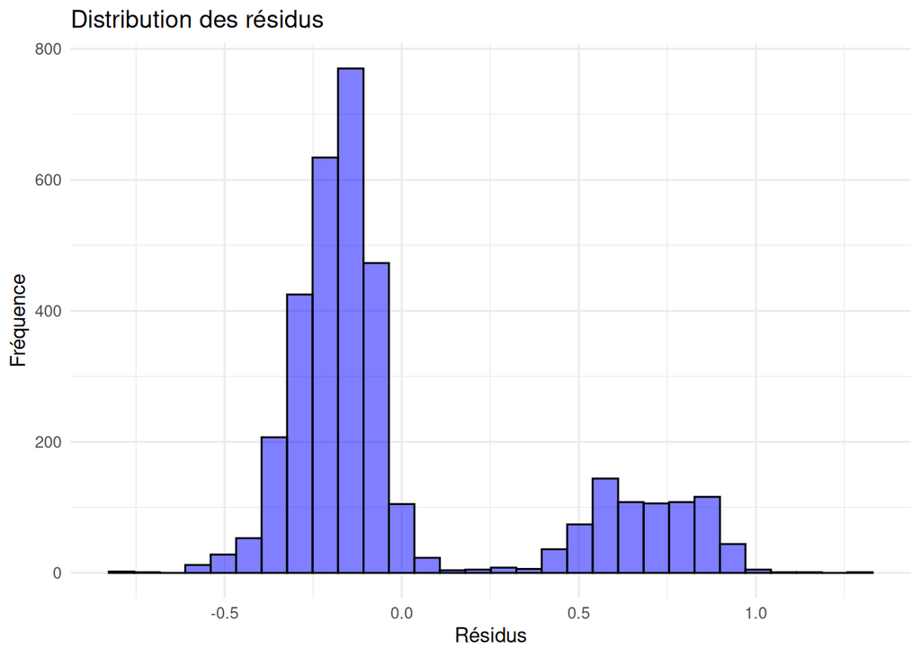

```r
ggplot(data.frame(residuals = residuals(iv_model3)), aes(x = residuals)) +
  geom_histogram(bins = 30, fill = "blue", alpha = 0.5, color = "black") +
  theme_minimal() +
  labs(title = "Distribution des résidus", x = "Résidus", y = "Fréquence")
```

2. Vérification de l’hétéroscédasticité (variance non constante des résidus)

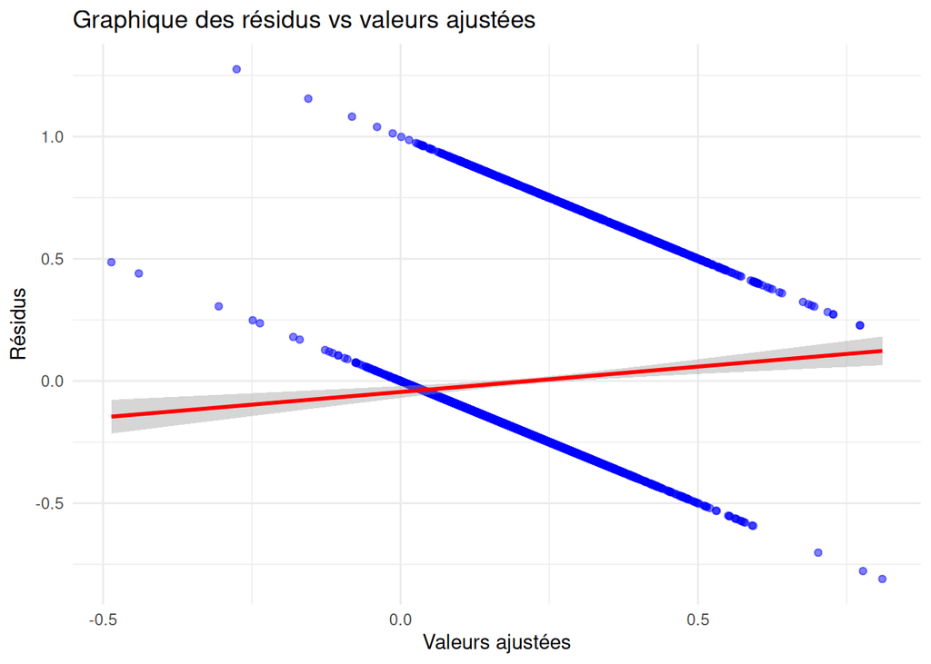

```r
ggplot(data.frame(fitted = fitted(iv_model3), residuals = residuals(iv_model3)), aes(x = fitted, y = residuals)) +
  geom_point(alpha = 0.5, color = "blue") +
  geom_smooth(method = "lm", color = "red") +
  theme_minimal() +
  labs(title = "Graphique des résidus vs valeurs ajustées", x = "Valeurs ajustées", y = "Résidus")
```

3. Vérification de l’autocorrélation des résidus (test de Durbin-Watson)

```r
library(lmtest)  # Pour le test de Durbin-Watson

dwtest(iv_model3)
```

```
##
##  Durbin-Watson test
##
## data:  iv_model3
## DW = 1.9738, p-value = 0.2194
## alternative hypothesis: true autocorrelation is greater than 0
```

La p-value est élevée → **pas d’autocorrélation**, bon signe !

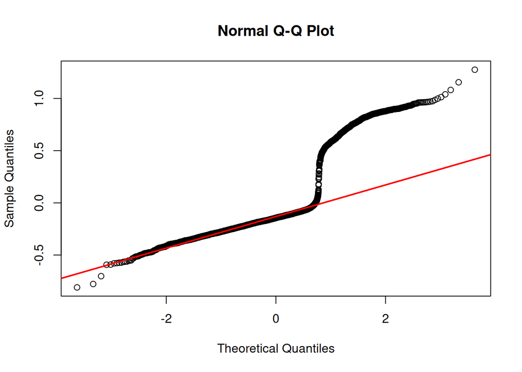

```r
qqnorm(residuals(iv_model3))
qqline(residuals(iv_model3), col = "red", lwd = 2)
```

### Matrice de confusion

```r
# Prédictions continues
predictions <- predict(iv_model3, newdata = test_data)

# Convertir en probabilités avec une fonction logistique (si nécessaire)
predicted_prob <- 1 / (1 + exp(-predictions))

# Convertir en classes : seuil de 0.5 pour la classification
predicted_class <- ifelse(predicted_prob >= 0.5, 1, 0)

# Charger le package nécessaire
library(caret)

# Générer la matrice de confusion
conf_matrix <- confusionMatrix(as.factor(predicted_class), as.factor(test_data$loan_status))

# Afficher la matrice de confusion
print(conf_matrix)
```

```
## Confusion Matrix and Statistics
##
##           Reference
## Prediction    0    1
##          0   28    2
##          1 1158  312
##
##                Accuracy : 0.2267
##                  95% CI : (0.2057, 0.2487)
##     No Information Rate : 0.7907
##     P-Value [Acc > NIR] : 1
##
##                   Kappa : 0.0073
##
##  Mcnemar's Test P-Value : <2e-16
##
##             Sensitivity : 0.02361
##             Specificity : 0.99363
##          Pos Pred Value : 0.93333
##          Neg Pred Value : 0.21224
##              Prevalence : 0.79067
##          Detection Rate : 0.01867
##    Detection Prevalence : 0.02000
##       Balanced Accuracy : 0.50862
##
##        'Positive' Class : 0
##
```

### Calculons l’AUC

AUC → Plus l’AUC est proche de 1, meilleur est le modèle.

```r
library(pROC)

# Calcul de l'AUC
auc_score <- roc(test_data$loan_status, predicted_prob)
auc(auc_score)
```

```
## Area under the curve: 0.7191
```

# V. Introduction complète à l’utilisation du package $ivreg$

Le package `ivreg` de R offre une implémentation complète de la régression par variables instrumentales en utilisant l’estimation des moindres carrés en deux étapes (2SLS). Il fournit des fonctionnalités étendues pour l’estimation des paramètres, l’inférence, les prédictions, ainsi que divers diagnostics de régression, tels que les valeurs de levier (hat values), les résidus studentisés et les distances de Cook. De plus, il intègre des outils graphiques pour les diagnostics, comme les graphiques composant-plus-résidu et les graphiques de variable ajoutée, ainsi que des graphiques d’effet avec résidus partiels.

Voici une présentation détaillée de l’utilisation du package `ivreg` dans un document R Markdown, incluant une application pratique.

## V.1- Petit rappel

La régression par variables instrumentales (IV) est une méthode utilisée pour estimer les relations causales lorsque les variables explicatives sont corrélées avec l’erreur du modèle, entraînant une endogénéité. Le package `ivreg` de R facilite l’estimation des modèles IV en utilisant les moindres carrés en deux étapes (2SLS) et offre divers outils de diagnostic pour évaluer la qualité du modèle.

## V.2- Installation et Chargement du Package

Pour installer le package `ivreg`, exécutez la commande suivante :

```r
install.packages("ivreg")
```

Ensuite, chargez le package :

```r
library(ivreg)
```

## V.3- Présentation des Données

Pour illustrer l’utilisation de `ivreg`, nous utiliserons le jeu de données `SchoolingReturns` inclus dans le package. Ce jeu de données provient d’une étude sur l’effet de la scolarité sur les revenus aux États-Unis.

Les principales variables sont :

- `wage` : Salaire.
- `education` : Années de scolarité.
- `experience` : Années d’expérience professionnelle.
- `ethnicity` : Ethnicité.
- `smsa` : Résidence en zone urbaine (oui/non).
- `south` : Résidence dans le sud des États-Unis (oui/non).
- `age` : Âge.
- `nearcollege` : Proximité d’un collège (oui/non).

Chargeons et examinons ces données :

```r
data("SchoolingReturns", package = "ivreg")
summary(SchoolingReturns[, 1:8])
```

```
##       wage          education       experience     ethnicity     smsa
##  Min.   : 100.0   Min.   : 1.00   Min.   : 0.000   other:2307   no : 864
##  1st Qu.: 394.2   1st Qu.:12.00   1st Qu.: 6.000   afam : 703   yes:2146
##  Median : 537.5   Median :13.00   Median : 8.000
##  Mean   : 577.3   Mean   :13.26   Mean   : 8.856
##  3rd Qu.: 708.8   3rd Qu.:16.00   3rd Qu.:11.000
##  Max.   :2404.0   Max.   :18.00   Max.   :23.000
##  south           age        nearcollege
##  no :1795   Min.   :24.00   no : 957
##  yes:1215   1st Qu.:25.00   yes:2053
##             Median :28.00
##             Mean   :28.12
##             3rd Qu.:31.00
##             Max.   :34.00
```

## V.4- Modèle de Régression OLS

Commençons par estimer un modèle de régression linéaire ordinaire (OLS) où le logarithme du salaire (`log(wage)`) est expliqué par les années de scolarité (`education`), l’expérience professionnelle (`experience`), l’ethnicité (`ethnicity`), la résidence en zone urbaine (`smsa`) et la résidence dans le sud (`south`) :

```r
m_ols <- lm(log(wage) ~ education + poly(experience, 2) + ethnicity + smsa + south,
            data = SchoolingReturns)
summary(m_ols)
```

```
##
## Call:
## lm(formula = log(wage) ~ education + poly(experience, 2) + ethnicity +
##     smsa + south, data = SchoolingReturns)
##
## Residuals:
##      Min       1Q   Median       3Q      Max
## -1.59297 -0.22315  0.01893  0.24223  1.33190
##
## Coefficients:
##                       Estimate Std. Error t value Pr(>|t|)
## (Intercept)           5.259820   0.048871 107.626  < 2e-16 ***
## education             0.074009   0.003505  21.113  < 2e-16 ***
## poly(experience, 2)1  8.931699   0.494804  18.051  < 2e-16 ***
## poly(experience, 2)2 -2.642043   0.374739  -7.050 2.21e-12 ***
## ethnicityafam        -0.189632   0.017627 -10.758  < 2e-16 ***
## smsayes               0.161423   0.015573  10.365  < 2e-16 ***
## southyes             -0.124862   0.015118  -8.259  < 2e-16 ***
## ---
## Signif. codes:  0 '***' 0.001 '**' 0.01 '*' 0.05 '.' 0.1 ' ' 1
##
## Residual standard error: 0.3742 on 3003 degrees of freedom
## Multiple R-squared:  0.2905, Adjusted R-squared:  0.2891
## F-statistic: 204.9 on 6 and 3003 DF,  p-value: < 2.2e-16
```

## V.5- Modèle de Régression IV avec `ivreg`

L’endogénéité potentielle de la variable `education` peut biaiser les estimations OLS. Pour corriger cela, nous utilisons la variable instrumentale `nearcollege`, qui indique si l’individu vivait à proximité d’un collège à 14 ans. Nous estimons le modèle IV en utilisant la fonction `ivreg` :

```r
library(ivreg)
m_iv <- ivreg(log(wage) ~ education + poly(experience, 2) + ethnicity + smsa + south |
              nearcollege + poly(experience, 2) + ethnicity + smsa + south,
              data = SchoolingReturns)
summary(m_iv)
```

```
##
## Call:
## ivreg(formula = log(wage) ~ education + poly(experience, 2) +
##     ethnicity + smsa + south | nearcollege + poly(experience,
##     2) + ethnicity + smsa + south, data = SchoolingReturns)
##
## Residuals:
##      Min       1Q   Median       3Q      Max
## -1.82125 -0.24065  0.02368  0.25469  1.43205
##
## Coefficients:
##                      Estimate Std. Error t value Pr(>|t|)
## (Intercept)           4.48649    0.65348   6.866 8.01e-12 ***
## education             0.13229    0.04923   2.687  0.00725 **
## poly(experience, 2)1 14.16811    4.44152   3.190  0.00144 **
## poly(experience, 2)2 -2.69296    0.39395  -6.836 9.84e-12 ***
## ethnicityafam        -0.13080    0.05287  -2.474  0.01342 *
## smsayes               0.13132    0.03013   4.359 1.35e-05 ***
## southyes             -0.10490    0.02307  -4.546 5.67e-06 ***
##
## Diagnostic tests:
##                   df1  df2 statistic  p-value
## Weak instruments    1 3003    16.718 4.45e-05 ***
## Wu-Hausman          1 3002     1.539    0.215
## Sargan              0   NA        NA       NA
## ---
## Signif. codes:  0 '***' 0.001 '**' 0.01 '*' 0.05 '.' 0.1 ' ' 1
##
## Residual standard error: 0.391 on 3003 degrees of freedom
## Multiple R-Squared: 0.2252,  Adjusted R-squared: 0.2237
## Wald test: 120.8 on 6 and 3003 DF,  p-value: < 2.2e-16
```

## V.6- Diagnostics du Modèle IV

Nous pouvons également tracer les résidus studentisés :

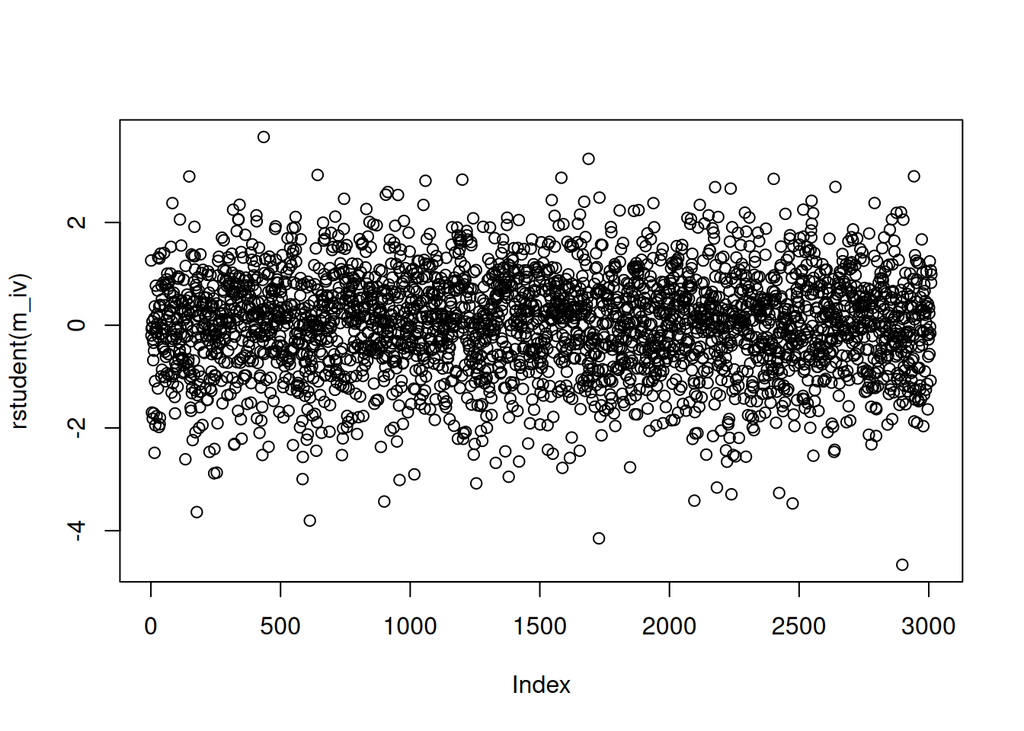

```r
plot(rstudent(m_iv))
```

## Conclusion

Le problème d’engogénéité est un facteur très important à prendre en compte dans nos analyse car cela peut biaser nos estimations et entrainer la prise de mauvaise décision. Faisons donc très attention aux résultats de nos modèles car ils peuvent être biaisés.

Le package `ivreg` de R fournit une interface conviviale pour estimer des modèles de régression par variables instrumentales, tout en offrant des outils diagnostics pour évaluer la validité des instruments et la qualité de l’ajustement du modèle. Son intégration avec d’autres packages tels que `car` et `effects` facilite l’analyse et l’interprétation des résultats.

**NB:** Pour des travaux plus complexe, vous pouvez utiliser le package $ivtools$ qui est vraiment super. Voici la documentation pour ceux et celles qui sont interéssés(es) [ici](https://cran.r-project.org/web/packages/ivtools/ivtools.pdf)

Ce document R Markdown présente l’importance de l’utilisation de la régression de variables instrumentales dans l’analyse de risque de crédits ainsi qu’une introduction complète à l’utilisation du package `ivreg` pour effectuer des régressions par variables instrumentales, en mettant l’accent sur l’estimation, l’interprétation et les diagnostics du modèle.